# Clean data

Camila Diaz

2026-06-05

```r
library(dplyr)
library(ggplot2)
library(tidyr)
library(sf)
library(geodata)
```

# Code overview

This document creates a **presence-absence dataset** for the Monarch butterfly (*Danaus plexippus*) from a complete-checklist citizen science dataset.

- **Presences**: checklists where the Monarch was recorded
- **Absences**: completed checklists in the same season where no Monarch was reported
- **Season filter**: June, July, and August (core North American breeding season)

```r
# Load data
dat <- read.csv("C:/Users/maria/Documents/GitHub/Expert_SDM/data/species/records_clean_gbif.csv")

summary_table <- data.frame(
  column_name = names(dat),
  unique_values = sapply(dat, function(x) length(unique(x))),
  na_count = sapply(dat, function(x) sum(is.na(x)))
)
```

## Filter to the breeding season

We retain only records from **June (6), July (7), and August (8)**, which represent the core summer breeding window for Monarchs across North America.

```r
breeding_months <- 6:8

breeding_checklists <- dat |>
  filter(month %in% breeding_months)

cat("Checklists in breeding season:", n_distinct(breeding_checklists$Checklist.ID), "\n")
```

```
## Checklists in breeding season: 59614
```

## Identify Monarch presences

Extract all checklist IDs where *Danaus plexippus* was recorded.  
Each unique checklist ID gets a `presence = 1` flag.

```r
monarch_present <- breeding_checklists |>
  dplyr::filter(Species_name == "Danaus plexippus") |>
  dplyr::select(Checklist.ID) |>
  distinct() |>
  mutate(presence = 1)

cat("Checklists with Monarch present:", nrow(monarch_present), "\n")
```

```
## Checklists with Monarch present: 8120
```

## Build checklist-level metadata

Each checklist may contain many species rows, but spatial and temporal information is constant within a checklist. We collapse to one row per checklist using `slice(1)`.

```r
checklist_meta <- breeding_checklists |>
  group_by(Checklist.ID) |>
  slice(1) |>
  ungroup() |>
  dplyr::select(Checklist.ID, Site.ID, Latitude, Longitude,
         year, month, Sampling.protocol, Party.Size, Observer)
```

## Create the presence-absence dataset

A left join assigns `presence = 1` to checklists where the Monarch was seen. All unmatched checklists receive `NA`, which is then replaced with `0` (confirmed absence — the observer was present but did not record the species).

```r
presence_absence <- checklist_meta |>
  left_join(monarch_present, by = "Checklist.ID") |>
  mutate(presence = replace_na(presence, 0))
```

## Sanity check

Verify the counts and prevalence before proceeding to modelling.

```r
cat("Total checklists (breeding season):", nrow(presence_absence), "\n")
```

```
## Total checklists (breeding season): 59614
```

```r
cat("Presence (1):                     ", sum(presence_absence$presence == 1), "\n")
```

```
## Presence (1):                      8120
```

```r
cat("Absence  (0):                     ", sum(presence_absence$presence == 0), "\n")
```

```
## Absence  (0):                      51494
```

```r
cat("Prevalence (%):                   ",
    round(mean(presence_absence$presence) * 100, 2), "\n")
```

```
## Prevalence (%):                    13.62
```

## Map presence and absence

The map below shows all breeding-season checklists. Orange points are sites where the Monarch was recorded; grey points are sites where checklists were completed but no Monarch was observed.

```r
# Factor with absence first so presences plot on top
presence_absence$presence_f <- factor(
  presence_absence$presence,
  levels = c(0, 1),
  labels = c("Absence", "Presence")
)

dat_spatial <- st_as_sf(presence_absence,
                        coords = c("Longitude", "Latitude"),
                        crs = 4326)

study_area0 <- st_read("C:/Users/maria/Documents/GitHub/Expert_SDM/data/study_area/canada.shp")
PA_data <- st_intersection(dat_spatial, study_area0)

cat("Total checklists (breeding season):", nrow(PA_data), "\n")
```

```
## Total checklists (breeding season): 33016
```

```r
cat("Presence (1):                     ", sum(PA_data$presence == 1), "\n")
```

```
## Presence (1):                      4599
```

```r
cat("Absence  (0):                     ", sum(PA_data$presence == 0), "\n")
```

```
## Absence  (0):                      28417
```

```r
cat("Prevalence (%):                   ",
    round(mean(PA_data$presence) * 100, 2), "\n")
```

```
## Prevalence (%):                    13.93
```

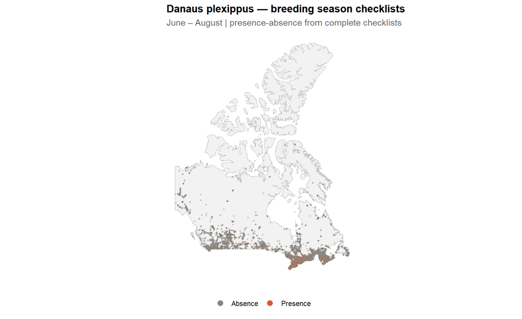

```r
epsg = 3857
study_area0 <- study_area0 |>
  st_transform(crs = epsg)

PA_data <- PA_data |>
  st_transform(crs = epsg)


m <- ggplot() +
  geom_sf(data = study_area0, fill = "grey95", color = "grey70") +
  geom_sf(data = PA_data, aes(colour = presence_f), alpha = 0.4, size = 0.8, shape = 16) +
  scale_colour_manual(
    name   = NULL,
    values = c("Absence"  = "#888780",
               "Presence" = "#D85A30"),
    guide  = guide_legend(override.aes = list(size = 3, alpha = 1))
  ) +
  labs(
    title    = "Danaus plexippus — breeding season checklists",
    subtitle = "June – August | presence-absence from complete checklists"
  ) +
  theme_minimal() +
  theme(
    legend.position   = "bottom",
    axis.text         = element_blank(),
    plot.title        = element_text(face = "bold"),
    plot.subtitle     = element_text(colour = "grey40"),
    panel.grid        = element_blank()
  )
m
```

## Spatial thinning — one checklist per 1 km grid cell

To reduce spatial autocorrelation and sampling bias we overlay a 1 km × 1 km grid and keep a single record per cell. Where a cell contains both presences and absences, the presence is retained, this avoids introducing false absences in areas where the Monarch was genuinely detected.

### Create 1 km Hexagonal Grid over Study Area

```r
library(h3jsr)
crs_quebec <- 32198

occ_proj      <- st_transform(PA_data, crs_quebec)
study_area_proj <- st_transform(study_area0, crs_quebec)

hex_grid <- st_make_grid(
  study_area_proj,
  cellsize    = 1000,
  what        = "polygons",
  square      = FALSE,
  flat_topped = TRUE
)
```

### Spatially Join Occurrences to Grid

```r
hex_sf <- st_sf(hex_id = seq_along(hex_grid), geometry = hex_grid)

# Join occurrences to hexagons
occ_hex <- st_join(occ_proj, hex_sf, join = st_within)

# Thin: keep 1 record per hexagon, prioritizing presences (presence == 1)
occ_thinned <- occ_hex %>%
  st_drop_geometry() %>%
  group_by(hex_id) %>%
  arrange(desc(presence), .by_group = TRUE) %>%  # presences (1) sort before absences (0)
  slice(1) %>%
  ungroup()

# Rejoin geometry from original data
occ_thinned <- occ_proj %>%
  filter(Checklist.ID %in% occ_thinned$Checklist.ID)

cat("Original records:", nrow(occ_proj), "\n")
```

```
## Original records: 33016
```

```r
cat("Thinned records: ", nrow(occ_thinned), "\n")
```

```
## Thinned records:  10382
```

```r
cat("Presences kept:  ", sum(occ_thinned$presence == 1), "\n")
```

```
## Presences kept:   1931
```

```r
cat("Absences kept:   ", sum(occ_thinned$presence == 0), "\n")
```

```
## Absences kept:    8451
```

```r
#st_write(occ_thinned,"C:/Users/maria/Documents/GitHub/Expert_SDM/data/species/PA_monarch_CAN.shp")
```

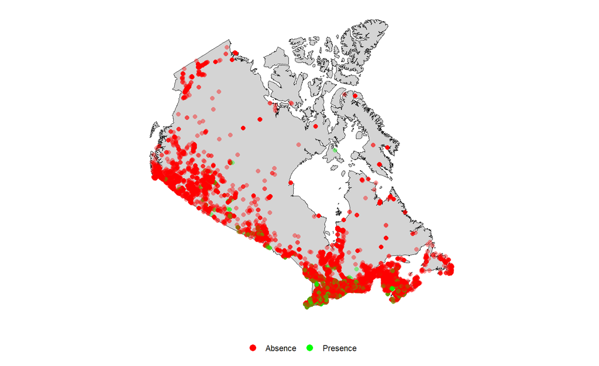

```r
m <- ggplot() +
  geom_sf(data = study_area_proj, fill = "grey83", color = "black") +
  geom_sf(data = PA_data, aes(colour = presence_f), alpha = 0.4, size = 2, shape = 16) +
  scale_colour_manual(
    name   = NULL,
    values = c("Absence"  = "red",
               "Presence" = "green"),
    guide  = guide_legend(override.aes = list(size = 3, alpha = 1))
  ) +
  theme_minimal() +
  theme(
    legend.position   = "bottom",
    axis.text         = element_blank(),
    panel.grid        = element_blank()
  )
m
```

```r
ggsave(paste0("C:/Users/maria/Documents/GitHub/Expert_SDM/results/data_100.png"), plot = m, width = 8, height = 8, dpi = 300)
```